# The intelligent beer: Machine Lite

October 15, 2018

## Introduction

## QQTD: Given the datasets Beer and Brews, we want to know:

### -Where our headquaters should be?

### -What style of beer would appeal to the widest audience?

### -If we wanted to have a high ABV, what is the ideal IBU?

## The Data

| BeerName | Beer_ID | ABV | IBU | Style | Ounces | BreweryName | Brewery_ID | City | State |
| --- | --- | --- | --- | --- | --- | --- | --- | --- | --- |
| Get Together | 2692 | 0.045 | 50 | American IPA | 16 | NorthGate Brewing | 1 | Minneapolis | MN |
| Maggie's Leap | 2691 | 0.049 | 26 | Milk / Sweet Stout | 16 | NorthGate Brewing | 1 | Minneapolis | MN |
| Wall's End | 2690 | 0.048 | 19 | English Brown Ale | 16 | NorthGate Brewing | 1 | Minneapolis | MN |
| Pumpion | 2689 | 0.060 | 38 | Pumpkin Ale | 16 | NorthGate Brewing | 1 | Minneapolis | MN |
| Stronghold | 2688 | 0.060 | 25 | American Porter | 16 | NorthGate Brewing | 1 | Minneapolis | MN |
| Parapet ESB | 2687 | 0.056 | 47 | Extra Special / Strong Bitter (ESB) | 16 | NorthGate Brewing | 1 | Minneapolis | MN |

#### Caption: Here is a quick glance at the head of our merged dataset. You can see we created easy to read captions and merged the two raw datasets with our renames field "Brewery_ID".

#### Here are the first 6 rows of our merged data set.

## The Data (continued)

|  | BeerName | Beer_ID | ABV | IBU | Style | Ounces | BreweryName | Brewery_ID | City | State |
| --- | --- | --- | --- | --- | --- | --- | --- | --- | --- | --- |
| 2405 | Pilsner Ukiah | 98 | 0.055 | NA | German Pilsener | 12 | Ukiah Brewing Company | 556 | Ukiah | CA |
| 2406 | Heinnieweisse Weissebier | 52 | 0.049 | NA | Hefeweizen | 12 | Butternuts Beer and Ale | 557 | Garrattsville | NY |
| 2407 | Snapperhead IPA | 51 | 0.068 | NA | American IPA | 12 | Butternuts Beer and Ale | 557 | Garrattsville | NY |
| 2408 | Moo Thunder Stout | 50 | 0.049 | NA | Milk / Sweet Stout | 12 | Butternuts Beer and Ale | 557 | Garrattsville | NY |
| 2409 | Porkslap Pale Ale | 49 | 0.043 | NA | American Pale Ale (APA) | 12 | Butternuts Beer and Ale | 557 | Garrattsville | NY |
| 2410 | Urban Wilderness Pale Ale | 30 | 0.049 | NA | English Pale Ale | 12 | Sleeping Lady Brewing Company | 558 | Anchorage | AK |

#### Caption: Here is a quick glance at the tail of our merged dataset. You can see we created easy to read captions and merged the two raw datasets with our renames field "Brewery_ID".

#### Here are the last 6 rows of our merged data set.

## The Data: Median Values and Breweries by State

| State | medianABV | medianIBU | NumBreweries |
| --- | --- | --- | --- |
| AK | 0.0560 | 46.0 | 7 |
| AL | 0.0600 | 43.0 | 3 |
| AR | 0.0520 | 39.0 | 2 |
| AZ | 0.0550 | 20.5 | 11 |
| CA | 0.0580 | 42.0 | 39 |
| CO | 0.0605 | 40.0 | 47 |

#### In order to make the dataset more friendly for analysis, we created a new dataset from our merged dataset that would look at the median ABVs and IBUs, along with the number of breweries for each state.

## Missing Values

#### The next logical step in analyzing the dataset was to find missing values.

```
##             na_count
## BeerName           0
## Beer_ID            0
## ABV               62
## IBU             1005
## Style              0
## Ounces             0
## BreweryName        0
## Brewery_ID         0
## City               0
## State              0
```

There are 62 missing data points for ABV, and 1005 missing data points for IBU.

## Graphics: Number of Breweries

[interactive chart not shown]

#### We can see that the Colorado has the darkest coloring on the graph which alludes to the highest number of breweries! Colorado contains 47 breweries. California, Oregon, Texas and Washington fall behind with 39, 29, 28, and 23 breweries.

## Graphics: Analysis on ABV

[interactive chart not shown]

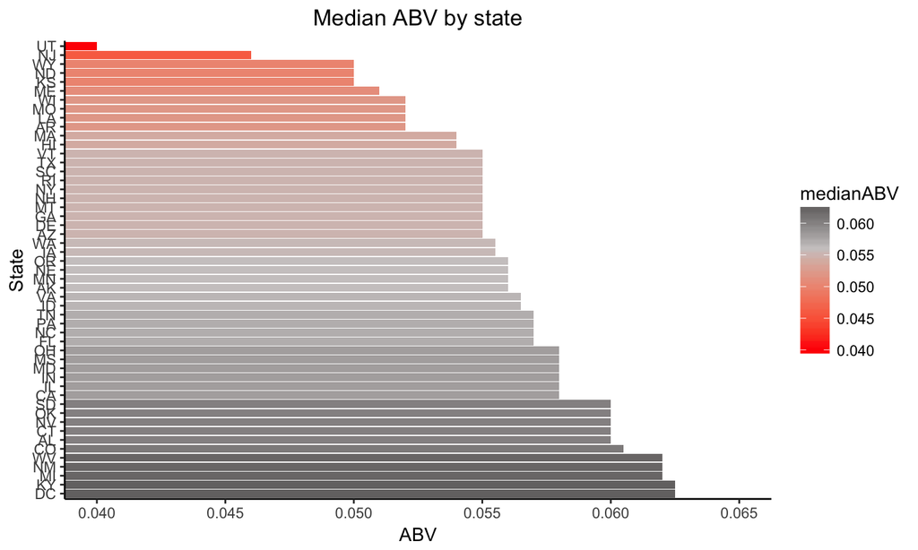

## Maximum ABV

```
## # A tibble: 1 x 4
##   State                                             BeerName    City   ABV
##   <chr>                                                <chr>   <chr> <dbl>
## 1    CO Lee Hill Series Vol. 5 - Belgian Style Quadrupel Ale Boulder 0.128
```

#### Colorado has the most alcoholic beer of any state! Lee Hill Series Vol. 5, a Belgian Style Quadrupel Ale produced in Boulder,CO has an ABV of 12.8%

## Graphics: Analysis on IBU

[interactive chart not shown]

## Median IBU

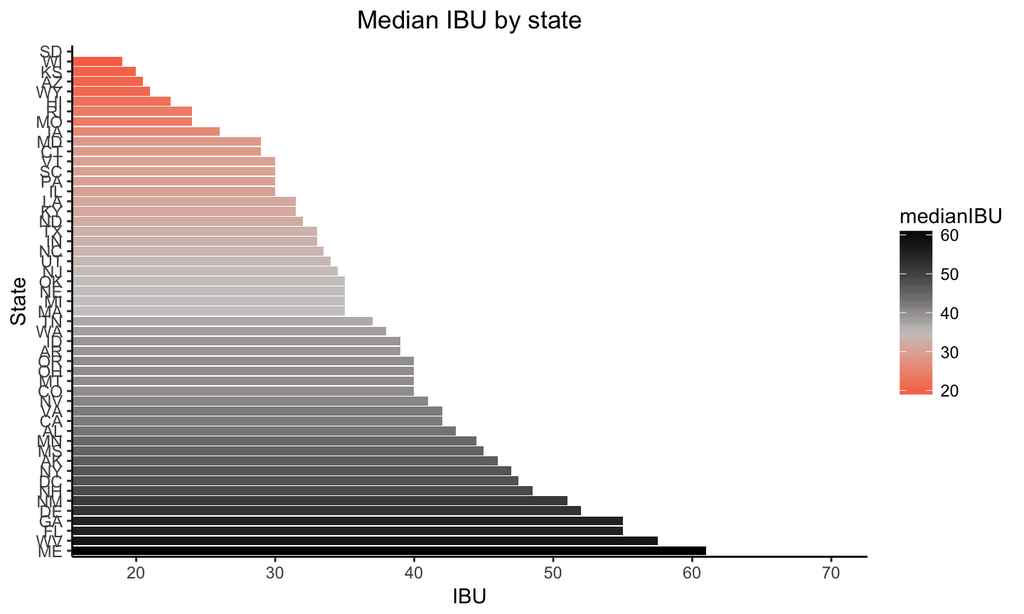

## Maximum IBU

```
## # A tibble: 1 x 4
##   State                  BeerName    City   IBU
##   <chr>                     <chr>   <chr> <int>
## 1    OR Bitter Bitch Imperial IPA Astoria   138
```

#### Oregon has the bitterest beer of any state! Bitter Bitch Imperial IPA, produced in Astoria, has an IBU of 138!

## Graphics: Analysis on ABV vs IBU

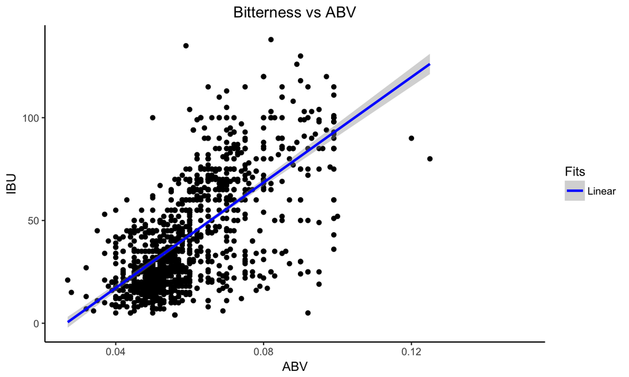

## Another view: ABV vs IBU for All Beers

[interactive chart not shown]

## More Style Analysis

[interactive chart not shown]

#### You can see here that the market is saturated with American IPA's.

## Numbers: Summary Statistics

## Summary Statistics for ABV

```
##    Min. 1st Qu.  Median    Mean 3rd Qu.    Max.    NA's
## 0.00100 0.05000 0.05600 0.05977 0.06700 0.12800      62
```

## Summary Statistics for IBU

```
##    Min. 1st Qu.  Median    Mean 3rd Qu.    Max.    NA's
##    4.00   21.00   35.00   42.71   64.00  138.00    1005
```